# 📊 Análisis de Datos y Visualización - Trabajo Final

# Ciclo de vida del proyecto:

- Comprensión del Problema 🙋
- Recolección de Datos 📂
- Análisis Exploratorio de Datos -EDA 📜
- Preparación de Datos 🔧
- Métodos predictivos 🎓
- Validación de los métodos predictivos 🚀

### 1. Comprensión del Problema

El objetivo es predecir los costos de seguros médicos (Insurance_Charges) basados en varias características de los individuos como edad, género, índice de masa corporal (BMI), número de hijos, estado de fumador y región.

### 2. Recolección de datos

**Fuente de datos:** [Kaggle Dataset](https://www.kaggle.com/datasets/muhammadanwaar101/healthcare-insurance-charges-dataset)

#### 2.1. Información del dataset

- **AGE:** Edad (Años).
- **Gender:** Género (Male / Female).
- **Body_Mass_Index (BMI):** Índice de masa corporal.
- **Number_of_Children:** Número de hijos que tiene la persona asegurada.
- **Smoking_Status:** Fumador (yes/no).
- **Region:** Región donde vive la persona asegurada.
- **Insurance_Charges:** Cargos del seguro médico (Valor a predecir).

#### 2.2 Importar datos y librerías

```python
!pip install pandas seaborn matplotlib pytz scikit-learn
```

```python
import pandas as pd
from urllib.parse import quote_plus
import seaborn as sns
import matplotlib.pyplot as plt
import pytz
import os
import math
from sklearn.preprocessing import OneHotEncoder
```

```python
## 1. Carga de datos
repo_path = "trabajofinal-analisis"
repo_url = "https://github.com/bdportilla1/trabajofinal-analisis.git"
if not os.path.exists(repo_path):
    !git clone {repo_url}
else:
    %cd {repo_path}
    !git pull
```

```
c:\Roberto\Maestría\Analisis de datos\TrabajoFinal\trabajofinal-analisis
```

```
c:\Roberto\Maestría\Analisis de datos\TrabajoFinal\venv_final\Lib\site-packages\IPython\core\magics\osm.py:417: UserWarning: This is now an optional IPython functionality, setting dhist requires you to install the `pickleshare` library.
  self.shell.db['dhist'] = compress_dhist(dhist)[-100:]
```

```
Already up to date.
```

```python
# Importar fuente de datos
ruta = 'insurance.csv'
data = pd.read_csv(ruta)
```

#### 2.3 Tamaño del dataset

```python
data.shape
```

```
(1407, 7)
```

El dataset tiene un tamaño de 1407 filas y 7 columnas.

#### 2.4 Mostrar las 5 primeras filas

```python
data.head(5)
```

|  | AGE | Gender | Body_Mass_Index(BMI) | Number_of_Children | Smoking_Status | Region | Insurance_Charges |
| --- | --- | --- | --- | --- | --- | --- | --- |
| 0 | 19 | female | 27.900 | 0 | yes | southwest | 16884.92400 |
| 1 | 18 | male | 33.770 | 1 | no | southeast | 1725.55230 |
| 2 | 28 | male | 33.000 | 3 | no | southeast | 4449.46200 |
| 3 | 33 | male | 22.705 | 0 | no | northwest | 21984.47061 |
| 4 | 32 | male | 28.880 | 0 | no | northwest | 3866.85520 |

#### 2.5 Visión general del dataset

```python
data.info()
```

```
<class 'pandas.core.frame.DataFrame'>
RangeIndex: 1407 entries, 0 to 1406
Data columns (total 7 columns):
 #   Column                Non-Null Count  Dtype
---  ------                --------------  -----
 0   AGE                   1407 non-null   int64
 1   Gender                1407 non-null   object
 2   Body_Mass_Index(BMI)  1407 non-null   float64
 3   Number_of_Children    1407 non-null   int64
 4   Smoking_Status        1407 non-null   object
 5   Region                1407 non-null   object
 6   Insurance_Charges     1407 non-null   float64
dtypes: float64(2), int64(2), object(3)
memory usage: 77.1+ KB
```

#### 2.6 Resumen de estadísticas numéricas

```python
data.describe()
```

|  | AGE | Body_Mass_Index(BMI) | Number_of_Children | Insurance_Charges |
| --- | --- | --- | --- | --- |
| count | 1407.000000 | 1407.000000 | 1407.000000 | 1407.000000 |
| mean | 39.262260 | 30.650522 | 1.100213 | 13221.434629 |
| std | 14.073376 | 6.122686 | 1.216550 | 12104.109529 |
| min | 18.000000 | 15.960000 | 0.000000 | 1121.873900 |
| 25% | 27.000000 | 26.210000 | 0.000000 | 4742.306100 |
| 50% | 39.000000 | 30.305000 | 1.000000 | 9361.326800 |
| 75% | 51.000000 | 34.687500 | 2.000000 | 16359.170275 |
| max | 64.000000 | 53.130000 | 5.000000 | 63770.428010 |

#### Hallazgos:

##### AGE (Edad)

- **Promedio (mean)**: La edad promedio de los individuos en el conjunto de datos es de aproximadamente 39.26 años.
- **Desviación estándar (std)**: La desviación estándar es de aproximadamente 14.07 años, indicando que hay una variabilidad considerable en las edades.
- **Edad mínima (min)**: La edad mínima es de 18 años.
- **Percentil 25 (25%)**: El 25% de los individuos tienen 27 años o menos.
- **Mediana (50%)**: La mediana es de 39 años, lo que significa que el 50% de los individuos tienen 39 años o menos.
- **Percentil 75 (75%)**: El 75% de los individuos tienen 51 años o menos.
- **Edad máxima (max)**: La edad máxima es de 64 años.

##### Body Mass Index (BMI)

- **Promedio (mean)**: El índice de masa corporal promedio es de aproximadamente 30.65.
- **Desviación estándar (std)**: La desviación estándar es de aproximadamente 6.12, indicando que hay una variabilidad considerable en los valores de BMI.
- **BMI mínimo (min)**: El BMI mínimo es de 15.96.
- **Percentil 25 (25%)**: El 25% de los individuos tienen un BMI de 26.21 o menos.
- **Mediana (50%)**: La mediana es de 30.31, lo que significa que el 50% de los individuos tienen un BMI de 30.31 o menos.
- **Percentil 75 (75%)**: El 75% de los individuos tienen un BMI de 34.69 o menos.
- **BMI máximo (max)**: El BMI máximo es de 53.13.

##### Number of Children (Número de hijos)

- **Promedio (mean)**: El número promedio de hijos es de aproximadamente 1.10.
- **Desviación estándar (std)**: La desviación estándar es de aproximadamente 1.22, indicando que hay una variabilidad considerable en el número de hijos.
- **Número mínimo de hijos (min)**: El número mínimo de hijos es 0.
- **Percentil 25 (25%)**: El 25% de los individuos no tienen hijos.
- **Mediana (50%)**: La mediana es de 1, lo que significa que el 50% de los individuos tienen 1 hijo o menos.
- **Percentil 75 (75%)**: El 75% de los individuos tienen 2 hijos o menos.
- **Número máximo de hijos (max)**: El número máximo de hijos es 5.

#### 2.7 Resumen de estadísticas categóricas

```python
data.describe(include = ['object'])
```

|  | Gender | Smoking_Status | Region |
| --- | --- | --- | --- |
| count | 1407 | 1407 | 1407 |
| unique | 2 | 2 | 4 |
| top | male | no | southeast |
| freq | 712 | 1123 | 386 |

Hallazgos:

1. Gender (Género):

   Existen 1407 observaciones de género en el conjunto de datos, 2 categorías únicas ('female' y 'male'). La categoría 'male' es la más común, con 712 apariciones.
2. Smoking Status (Estado de fumador):

   Hay 1407 observaciones del estado de fumador en el conjunto de datos, 2 categorías únicas ('yes' y 'no'). La categoría 'no' es la más común, con 1123 apariciones, lo que indica que la mayoría de los individuos no fuman.
3. Region (Región):

   Hay 1407 observaciones de la región en el conjunto de datos, 4 categorías únicas ('southeast', 'southwest', 'northeast', 'northwest'). La categoría 'southeast' es la más común, con 386 apariciones, lo que podría implicar una concentración más alta de individuos en esta región.

### 3. Análisis exploratorio de Datos - EDA

- Distribución de datos.
- Densidad estimada - KDE

#### 3.1 Revisión de valores nulos

```python
data.isnull().sum()
```

```
AGE                     0
Gender                  0
Body_Mass_Index(BMI)    0
Number_of_Children      0
Smoking_Status          0
Region                  0
Insurance_Charges       0
dtype: int64
```

Hallazgos: No existen valores nulos en ninguna columna del dataset.

1. Completitud de los Datos: Los datos están completos para todas las variables. No hay valores perdidos, no se necesita realizar imputaciones o eliminar registros incompletos.
2. Calidad de los Datos: La ausencia de valores nulos indica que los datos son de buena calidad en términos de completitud.

#### 3.2 Revisión de valores duplicados

```python
data.duplicated().sum()
```

```
68
```

Hallazgos: Existen 68 filas duplicadas en el dataset.

#### 3.3 Distribución de variables numéricas con KDE

```
Distribución de variables numéricas:
```

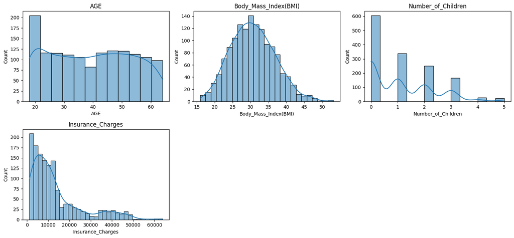

```python
int_vars = data.select_dtypes(include = ['int','float'])
num_vars = int_vars.shape[1]
num_rows = math.ceil(num_vars / 3)
print("Distribución de variables numéricas:")

fig, axs = plt.subplots(nrows=num_rows, ncols=3, figsize=(15,(num_rows*3)+1))
axs = axs.flatten()

for i, var in enumerate (int_vars):
  sns.histplot(x=var,data=data,ax=axs[i], kde=True)
  axs[i].set_title(var)
# Si hay más subplots que columnas, ocultar los subplots sobrantes
for j in range(i + 1, len(axs)):
  fig.delaxes(axs[j])

plt.tight_layout()
plt.show()
```

#### 3.4 Distribución de variables categóricas

```
Distribución de variables categóricas:
```

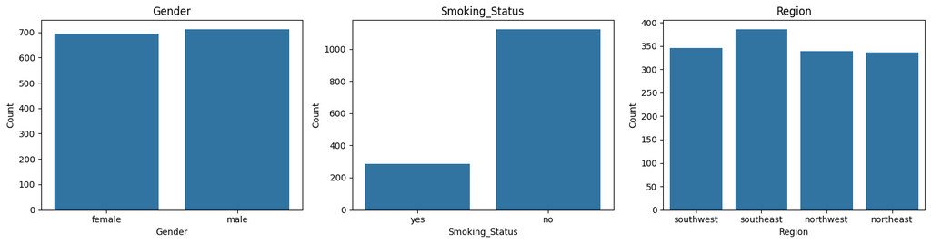

```python
cat_vars = data.select_dtypes(include=['object'])
num_vars = cat_vars.shape[1]
num_rows = math.ceil(num_vars / 3)
print("Distribución de variables categóricas:")

fig, axs = plt.subplots(nrows=num_rows, ncols=3, figsize=(15, (num_rows*3)+1))
axs = axs.flatten()

for i, var in enumerate(cat_vars):
    sns.countplot(x=var, data=data, ax=axs[i])
    axs[i].set_title(var)
    axs[i].set_ylabel('Count')
# Si hay más subplots que columnas, ocultar los subplots sobrantes
for j in range(i + 1, len(axs)):
    fig.delaxes(axs[j])

plt.tight_layout()
plt.show()
```

Hallazgos:

1. Gender (Género):

   La gráfica de barras muestra que hay una cantidad similar de individuos de género masculino y femenino, con una ligera predominancia del género masculino.
2. Smoking Status (Estado de fumador):

   La mayoría de los individuos en el conjunto de datos son no fumadores ('no'), mientras que una minoría significativa son fumadores ('yes').
3. Region (Región):

   La distribución de individuos por región muestra que las regiones 'southeast' y 'southwest' tienen una mayor representación en comparación con 'northwest' y 'northeast'.

#### 3.5 Distribución de datos

```
Boxplot de variables numéricas:
```

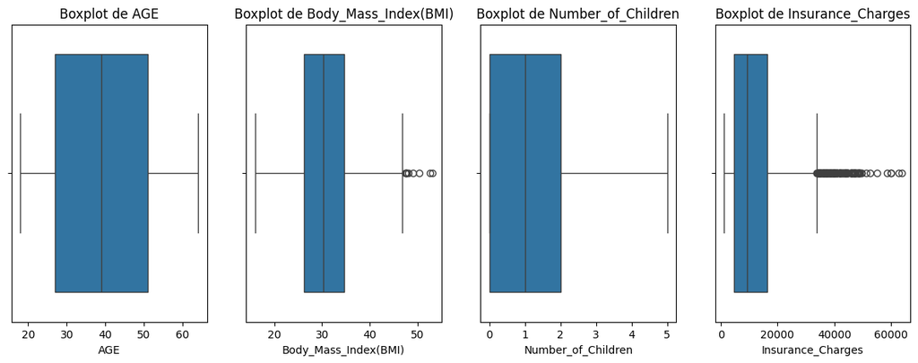

```python
# Boxplot de variables numéricas
print("Boxplot de variables numéricas:")

fig, axs = plt.subplots(nrows=num_rows, ncols=4, figsize=(15,(num_rows*4)+1))
axs = axs.flatten()

for i, columna in enumerate(int_vars.columns):
  sns.boxplot(data=int_vars[columna], orient="h", ax=axs[i])
  axs[i].set_title(f'Boxplot de {columna}')
# Si hay más subplots que columnas, ocultar los subplots sobrantes
for j in range(i + 1, len(axs)):
  fig.delaxes(axs[j])

plt.show()
```

#### 3.6 Matriz de correlación

Revisión del grado de asociación lineal entre dos variables cuantitativas.

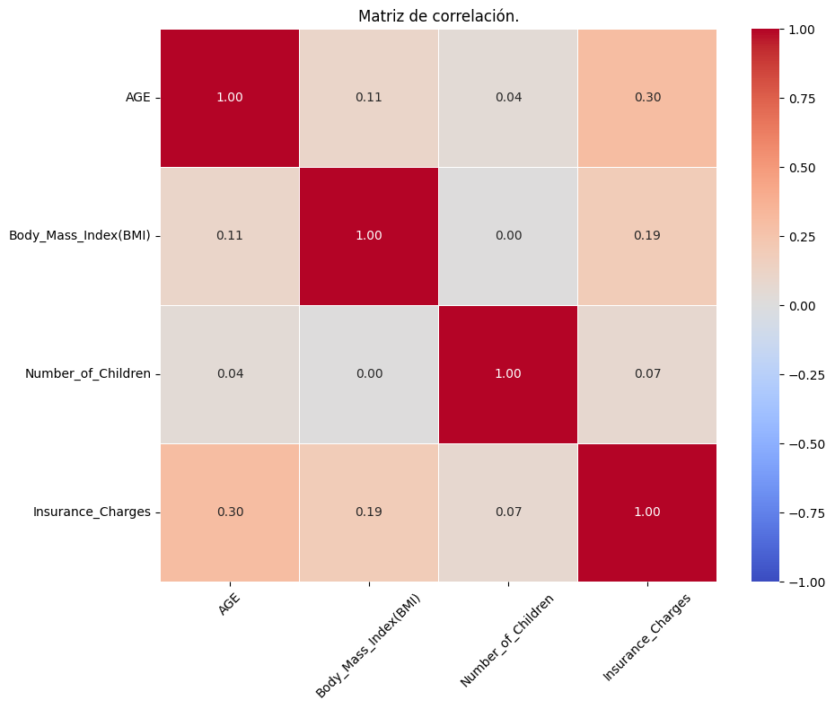

```python
# Filtrar las variables numéricas excluyendo 'Insurance_Charges'
numeric_columns = data.select_dtypes(include=['float64', 'int64'])

# Calcular la matriz de correlación
correlation_matrix = numeric_columns.corr()

# Crear una figura y un eje para la gráfica
plt.figure(figsize=(10, 8))

# Visualizar la matriz de correlación como un mapa de calor con anotaciones
sns.heatmap(correlation_matrix, annot=True, cmap='coolwarm', fmt=".2f", vmin=-1, vmax=1, linewidths=0.5)
plt.title('Matriz de correlación.')
plt.xticks(rotation=45)
plt.yticks(rotation=0)
plt.show()
```

Hallazgos:

1. Correlación entre AGE y BMI:
   - Puede haber una baja correlación positiva entre AGE y BMI, sugiriendo que la edad y el índice de masa corporal no están fuertemente relacionados.
2. Correlación entre AGE y Number_of_Children:
   - La correlación entre AGE y Number_of_Children podría ser baja, indicando que la edad no está fuertemente relacionada con el número de hijos./li>
3. Correlación entre BMI y Number_of_Children:
   - Puede haber una correlación muy baja o inexistente entre BMI y Number_of_Children, indicando que el índice de masa corporal y el número de hijos no están relacionados./li>

#### 3.7 Relación entre variables independientes y la variable dependiente.

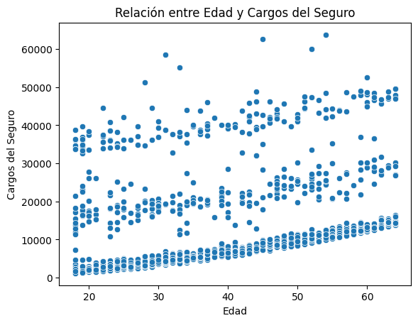

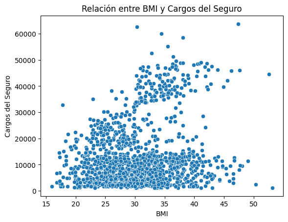

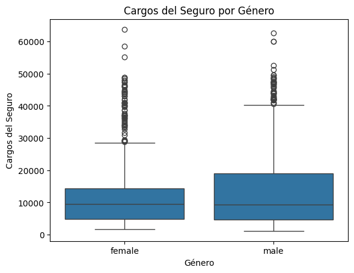

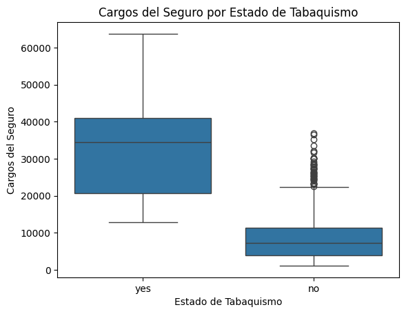

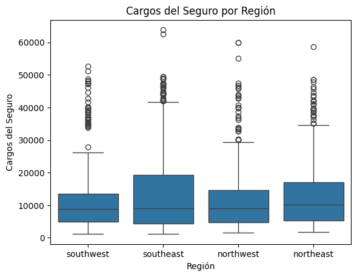

```python
# Relación entre edad y cargos del seguro
sns.scatterplot(x='AGE', y='Insurance_Charges', data=data)
plt.title('Relación entre Edad y Cargos del Seguro')
plt.xlabel('Edad')
plt.ylabel('Cargos del Seguro')
plt.show()

# Relación entre BMI y cargos del seguro
sns.scatterplot(x='Body_Mass_Index(BMI)', y='Insurance_Charges', data=data)
plt.title('Relación entre BMI y Cargos del Seguro')
plt.xlabel('BMI')
plt.ylabel('Cargos del Seguro')
plt.show()

# Boxplot de cargos del seguro por género
sns.boxplot(x='Gender', y='Insurance_Charges', data=data)
plt.title('Cargos del Seguro por Género')
plt.xlabel('Género')
plt.ylabel('Cargos del Seguro')
plt.show()

# Boxplot de cargos del seguro por estado de tabaquismo
sns.boxplot(x='Smoking_Status', y='Insurance_Charges', data=data)
plt.title('Cargos del Seguro por Estado de Tabaquismo')
plt.xlabel('Estado de Tabaquismo')
plt.ylabel('Cargos del Seguro')
plt.show()

# Boxplot de cargos del seguro por región
sns.boxplot(x='Region', y='Insurance_Charges', data=data)
plt.title('Cargos del Seguro por Región')
plt.xlabel('Región')
plt.ylabel('Cargos del Seguro')
plt.show()
```

### 4. Preparación de los datos

- Eliminación de datos duplicados.
- Codificación de variables - One Hot Encoding
- Normalización de variables

```python
data.drop_duplicates()
```

|  | AGE | Gender | Body_Mass_Index(BMI) | Number_of_Children | Smoking_Status | Region | Insurance_Charges |
| --- | --- | --- | --- | --- | --- | --- | --- |
| 0 | 19 | female | 27.900 | 0 | yes | southwest | 16884.92400 |
| 1 | 18 | male | 33.770 | 1 | no | southeast | 1725.55230 |
| 2 | 28 | male | 33.000 | 3 | no | southeast | 4449.46200 |
| 3 | 33 | male | 22.705 | 0 | no | northwest | 21984.47061 |
| 4 | 32 | male | 28.880 | 0 | no | northwest | 3866.85520 |
| ... | ... | ... | ... | ... | ... | ... | ... |
| 1335 | 18 | female | 36.850 | 0 | no | southeast | 1629.83350 |
| 1336 | 21 | female | 25.800 | 0 | no | southwest | 2007.94500 |
| 1337 | 61 | female | 29.070 | 0 | yes | northwest | 29141.36030 |
| 1372 | 41 | male | 24.940 | 1 | no | northeast | 6858.47960 |
| 1379 | 20 | female | 22.800 | 0 | yes | southwest | 20167.33603 |

1339 rows × 7 columns

#### 4.2 Codificación de variables.

```python
# One Hot Encoder
# Seleccionar columnas categóricas
categorical_columns = data.select_dtypes(include=['object']).columns.tolist()

# Codificar las columnas categóricas
encoder = OneHotEncoder(sparse_output=False)
one_hot_encoded = encoder.fit_transform(data[categorical_columns])
one_hot_data = pd.DataFrame(one_hot_encoded, columns=encoder.get_feature_names_out(categorical_columns))

# Concatenar las columnas codificadas con las otras columnas
data_encoded = pd.concat([data.drop(columns=categorical_columns), one_hot_data], axis=1)

# Mostrar el DataFrame resultante
print(data_encoded)
```

```
      AGE  Body_Mass_Index(BMI)  Number_of_Children  Insurance_Charges  \
0      19                27.900                   0        16884.92400
1      18                33.770                   1         1725.55230
2      28                33.000                   3         4449.46200
3      33                22.705                   0        21984.47061
4      32                28.880                   0         3866.85520
...   ...                   ...                 ...                ...
1402   34                27.720                   0         4415.15880
1403   42                37.900                   0         6474.01300
1404   51                36.385                   3        11436.73815
1405   54                27.645                   1        11305.93455
1406   55                37.715                   3        30063.58055

      Gender_female  Gender_male  Smoking_Status_no  Smoking_Status_yes  \
0               1.0          0.0                0.0                 1.0
```

[output cut: 25 more lines]

#### 4.3 Escalado de variables numéricas.

```python
from sklearn.preprocessing import StandardScaler

scaler = StandardScaler()
num_vars = ['AGE', 'Body_Mass_Index(BMI)', 'Number_of_Children']
data_encoded[num_vars] = scaler.fit_transform(data_encoded[num_vars])
#Verificar
print(data_encoded.head())
```

```
        AGE  Body_Mass_Index(BMI)  Number_of_Children  Insurance_Charges  \
0 -1.440270             -0.449394           -0.904693        16884.92400
1 -1.511352              0.509676           -0.082404         1725.55230
2 -0.800537              0.383870            1.562174         4449.46200
3 -0.445130             -1.298180           -0.904693        21984.47061
4 -0.516212             -0.289277           -0.904693         3866.85520

   Gender_female  Gender_male  Smoking_Status_no  Smoking_Status_yes  \
0            1.0          0.0                0.0                 1.0
1            0.0          1.0                1.0                 0.0
2            0.0          1.0                1.0                 0.0
3            0.0          1.0                1.0                 0.0
4            0.0          1.0                1.0                 0.0

   Region_northeast  Region_northwest  Region_southeast  Region_southwest
0               0.0               0.0               0.0               1.0
1               0.0               0.0               1.0               0.0
2               0.0               0.0               1.0               0.0
3               0.0               1.0               0.0               0.0
4               0.0               1.0               0.0               0.0
```

Hallazgos:

1. Estandarización de Variables:
   - AGE (Edad), Body Mass Index (BMI) y Number of Children (Número de hijos) han sido transformadas para tener una media de 0 y una desviación estándar de 1.
2. Impacto en los Datos:
   - Antes de la Estandarización: Las variables originales tenían diferentes escalas y rangos.
   - Después de la Estandarización: Todas las variables ahora tienen una media de 0 y una desviación estándar de 1, lo que las pone en la misma escala y facilita el análisis y la modelización.

#### 4.4 Exportar dataset procesado.

```python
data_encoded.to_csv('data_encoded.csv', index=False)
```

### 5. Métodos predictivos

- Datos de entranamiento y pruebas.
- Método 1: Regresión Lineal
- Método 2: Random Fores
- Máquinas de soporte vectorial

#### 5.1 División en conjuntos de entranamiento y prueba.

```python
from sklearn.model_selection import train_test_split


X = data_encoded.drop('Insurance_Charges', axis=1)
y = data_encoded['Insurance_Charges']

# Dividir los datos en conjuntos de entrenamiento y prueba
X_train, X_test, y_train, y_test = train_test_split(X, y, test_size=0.2, random_state=42)

# Mostrar las formas de los conjuntos para verificar
print(X_train.shape, X_test.shape, y_train.shape, y_test.shape)
```

```
(1125, 11) (282, 11) (1125,) (282,)
```

Hallazgos:

1. Proporción de División:
   - Tamaño del Conjunto de Prueba: El conjunto de prueba se establece en el 20% de los datos totales (test_size=0.2).
   - Tamaño del Conjunto de Entrenamiento: El conjunto de entrenamiento se establece en el 80% de los datos totales.
2. Formas de los Conjuntos:
   - Forma de X_train: (1125, 11) – Esto significa que el conjunto de entrenamiento contiene 1125 muestras y 11 características.
   - Forma de X_test: (282, 11) – Esto significa que el conjunto de prueba contiene 282 muestras y 11 características.
   - Forma de y_train: (1125,) – Esto significa que el conjunto de entrenamiento tiene 1125 etiquetas.
   - Forma de y_test: (282,) – Esto significa que el conjunto de prueba tiene 282 etiquetas.

#### 5.2 Método 1: Regresión Lineal.

```python
from sklearn.linear_model import LinearRegression
from sklearn.metrics import mean_squared_error, r2_score

# Crear el modelo de regresión lineal
model_lr = LinearRegression()
model_lr.fit(X_train, y_train)

# Hacer predicciones con los datos de prueba
y_pred_lr = model_lr.predict(X_test)

# Evaluar el modelo
mse_lr = mean_squared_error(y_test, y_pred_lr)
r2_lr = r2_score(y_test, y_pred_lr)

print(f'Regresión Lineal - Mean Squared Error: {mse_lr}')
print(f'Regresión Lineal - R-squared: {r2_lr}')
```

```
Regresión Lineal - Mean Squared Error: 37642444.282325506
Regresión Lineal - R-squared: 0.7896488151488128
```

Hallazgos:

1. Mean Squared Error (MSE):

Un R² de 0.7895 indica que aproximadamente el 78.95% de la variabilidad en los cargos del seguro (Insurance_Charges) puede ser explicada por el modelo de regresión lineal usando las características seleccionadas (AGE, Body_Mass_Index(BMI), Number_of_Children, y las columnas codificadas). Esto sugiere que el modelo tiene un buen ajuste, pero no perfecto. Un R² cercano a 1 indica un ajuste perfecto, mientras que un R² cercano a 0 indica que el modelo no explica bien la variabilidad de los datos.

#### 5.2 Método 2: Random Forest.

```python
import time
from sklearn.model_selection import GridSearchCV
from sklearn.metrics import mean_squared_error, r2_score
from sklearn.ensemble import RandomForestRegressor

# Crear el modelo base de bosques aleatorios
model_rf = RandomForestRegressor(random_state=42)
param_grid = {
    'n_estimators': [100, 200],
    'max_features': ['auto', 'sqrt'],
    'max_depth': [10, 20],
    'min_samples_split': [2, 5],
    'min_samples_leaf': [1, 2],
    'bootstrap': [True, False]
}
# Configurar GridSearchCV
grid_search = GridSearchCV(estimator=model_rf, param_grid=param_grid,
                           cv=3, n_jobs=-1, verbose=2, scoring='neg_mean_squared_error')
# Medir el tiempo de inicio
start_time = time.time()
# Ajustar el modelo con GridSearchCV
grid_search.fit(X_train, y_train)
# Medir el tiempo de finalización
end_time = time.time()
elapsed_time = end_time - start_time
# Obtener el mejor modelo
best_rf = grid_search.best_estimator_
# Hacer predicciones con los datos de prueba usando el mejor modelo
y_pred_rf = best_rf.predict(X_test)
# Evaluar el modelo
mse_rf = mean_squared_error(y_test, y_pred_rf)
r2_rf = r2_score(y_test, y_pred_rf)

print(f'Bosques Aleatorios Mejorados - Mean Squared Error: {mse_rf}')
print(f'Bosques Aleatorios Mejorados - R-squared: {r2_rf}')
print(f'Mejores Hiperparámetros: {grid_search.best_params_}')
print(f'Tiempo de ejecución: {elapsed_time} segundos')
```

```
Fitting 3 folds for each of 64 candidates, totalling 192 fits
```

[output not shown]

```
Bosques Aleatorios Mejorados - Mean Squared Error: 17793853.773736812
Bosques Aleatorios Mejorados - R-squared: 0.9005654841034921
Mejores Hiperparámetros: {'bootstrap': False, 'max_depth': 10, 'max_features': 'sqrt', 'min_samples_leaf': 2, 'min_samples_split': 2, 'n_estimators': 200}
Tiempo de ejecución: 27.38274645805359 segundos
```

#### 5.3 Método 3: Máquinas de soporte vectorial SVM.

```python
'''from sklearn.svm import SVR

# Crear el modelo SVM
model_svm = SVR(kernel='linear')
model_svm.fit(X_train, y_train)

# Hacer predicciones con los datos de prueba
y_pred_svm = model_svm.predict(X_test)

# Evaluar el modelo
mse_svm = mean_squared_error(y_test, y_pred_svm)
r2_svm = r2_score(y_test, y_pred_svm)

print(f'SVM - Mean Squared Error: {mse_svm}')
print(f'SVM - R-squared: {r2_svm}')
'''
from sklearn.model_selection import GridSearchCV
from sklearn.svm import SVR
from sklearn.metrics import mean_squared_error, r2_score

# Definir el grid de hiperparámetros para GridSearchCV
param_grid = {
    'kernel': ['linear', 'rbf', 'poly'],
    'C': [0.1, 1, 10, 100],
    'gamma': ['scale', 'auto']
}

# Configurar GridSearchCV
grid_search = GridSearchCV(SVR(), param_grid, cv=3, n_jobs=-1, verbose=2, scoring='neg_mean_squared_error')

# Ajustar el modelo con GridSearchCV
grid_search.fit(X_train, y_train)

# Obtener el mejor modelo
best_svm = grid_search.best_estimator_

# Hacer predicciones con los datos de prueba usando el mejor modelo
y_pred_svm = best_svm.predict(X_test)

# Evaluar el mejor modelo
mse_svm = mean_squared_error(y_test, y_pred_svm)
r2_svm = r2_score(y_test, y_pred_svm)

print(f'SVM Mejorado - Mean Squared Error: {mse_svm}')
print(f'SVM Mejorado - R-squared: {r2_svm}')
print(f'Mejores Hiperparámetros: {grid_search.best_params_}')
```

```
Fitting 3 folds for each of 24 candidates, totalling 72 fits
SVM Mejorado - Mean Squared Error: 77506536.28948188
SVM Mejorado - R-squared: 0.5668827555425466
Mejores Hiperparámetros: {'C': 100, 'gamma': 'scale', 'kernel': 'linear'}
```

### 6. Validación de métodos predictivos

- Evaluación de modelos.
- Conclusiones

#### 6.1 Evaluación de modelos

```python
# Imprimir los resultados
print(f'Regresión Lineal: Mean Squared Error: {mse_lr}, R-squared: {r2_lr}')
print(f'Bosques Aleatorios: Mean Squared Error: {mse_rf}, R-squared: {r2_rf}')
print(f'Máquinas de soporte vectorial SVM: Mean Squared Error: {mse_svm}, R-squared: {r2_svm}')
```

```
Regresión Lineal: Mean Squared Error: 37642444.282325506, R-squared: 0.7896488151488128
Bosques Aleatorios: Mean Squared Error: 17793853.773736812, R-squared: 0.9005654841034921
Máquinas de soporte vectorial SVM: Mean Squared Error: 77506536.28948188, R-squared: 0.5668827555425466
```

El modelo de bosques aleatrorios es el que mejor se ajusta ya que tine el menor error, lo que significa que las predicciones del modelo están más cerca de los valores reales y el R² tiene un valor más cercano 1, lo que significa que el modelo explica bien la variabilidad en los datos.

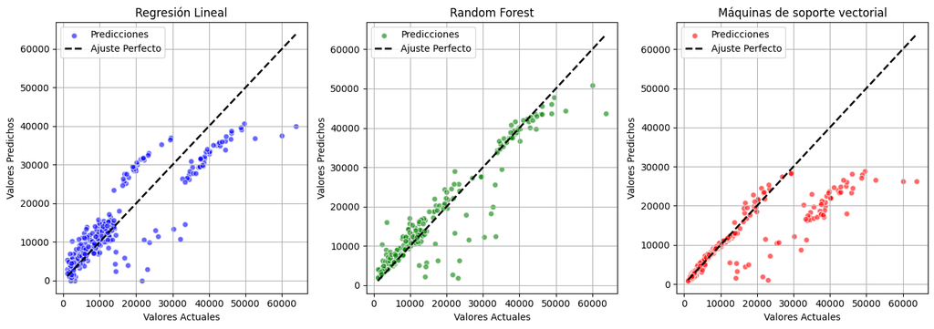

```python
import matplotlib.pyplot as plt

#Configurar tamaño para contener gráficas de los modelos
plt.figure(figsize=(14, 5))

# Gráfico de dispersión para visualizar las predicciones del modelo: Regresión Lineal
plt.subplot(1, 3, 1)
# Parámetros (valor reales y valores predichos) de la variable dependiente
plt.scatter(y_test, y_pred_lr, color='blue', edgecolor='w', alpha=0.6, label='Predicciones')
# Rango de parámetros para eje x y
plt.plot([y_test.min(), y_test.max()], [y_test.min(), y_test.max()], 'k--', lw=2, label='Ajuste Perfecto')
plt.xlabel('Valores Actuales')
plt.ylabel('Valores Predichos')
plt.title('Regresión Lineal')
plt.legend()
plt.grid(True)

# Gráfico de dispersión para visualizar las predicciones del modelo: Random Forest
plt.subplot(1, 3, 2)
# Parámetros (valor reales y valores predichos) de la variable dependiente
plt.scatter(y_test, y_pred_rf, color='green', edgecolor='w', alpha=0.6, label='Predicciones')
# Rango de parámetros para eje x y
plt.plot([y_test.min(), y_test.max()], [y_test.min(), y_test.max()], 'k--', lw=2, label='Ajuste Perfecto')
plt.xlabel('Valores Actuales')
plt.ylabel('Valores Predichos')
plt.title('Random Forest')
plt.legend()
plt.grid(True)

# Gráfico de dispersión para visualizar las predicciones del modelo: Random Forest
plt.subplot(1, 3, 3)
# Parámetros (valor reales y valores predichos) de la variable dependiente
plt.scatter(y_test, y_pred_svm, color='red', edgecolor='w', alpha=0.6, label='Predicciones')
# Rango de parámetros para eje x y
plt.plot([y_test.min(), y_test.max()], [y_test.min(), y_test.max()], 'k--', lw=2, label='Ajuste Perfecto')
plt.xlabel('Valores Actuales')
plt.ylabel('Valores Predichos')
plt.title('Máquinas de soporte vectorial')
plt.legend()
plt.grid(True)

plt.tight_layout()
plt.show()
```

Este código crea una figura con tres subplots, cada uno mostrando una gráfica de dispersión de los valores reales (y_test) contra los valores predichos (y_pred_lr, y_pred_rf, y_pred_svm). La línea discontinua negra representa una "perfect fit" donde los valores predichos serían exactamente iguales a los valores reales. Las gráficas de dispersión permiten visualizar la precisión de cada modelo y detectar cualquier patrón o discrepancia en las predicciones.

#### 6.2 Mátricas para evaluar los modelos

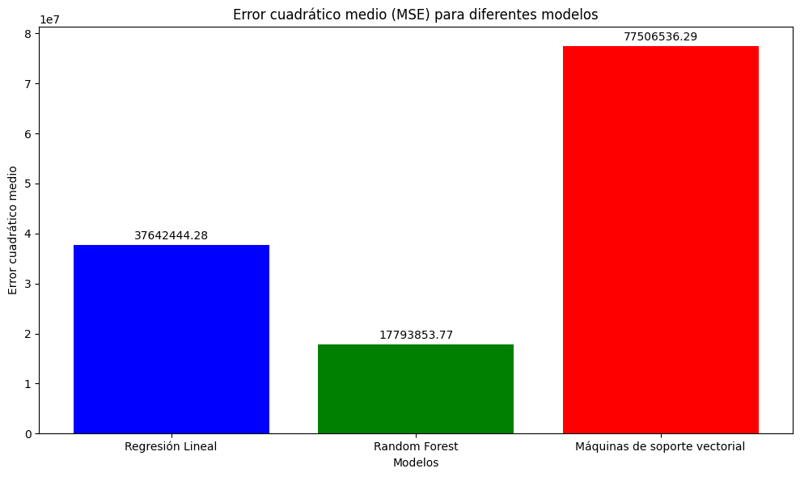

```python
import numpy as np
import matplotlib.pyplot as plt

# Datos para la gráfica del MSE
models = ['Regresión Lineal', 'Random Forest', 'Máquinas de soporte vectorial']
mse_values = [mse_lr, mse_rf, mse_svm]

# Creación del gráfico de barras para el MSE
fig, ax = plt.subplots(figsize=(10, 6))

# Barras para cada modelo
rects1 = ax.bar(models, mse_values, color=['blue', 'green', 'red'])

# Añadir etiquetas, título y leyenda
ax.set_xlabel('Modelos')
ax.set_ylabel('Error cuadrático medio')
ax.set_title('Error cuadrático medio (MSE) para diferentes modelos')

# Añadir valores en las barras
def add_labels(rects):
    for rect in rects:
        height = rect.get_height()
        ax.annotate(f'{height:.2f}',
                    xy=(rect.get_x() + rect.get_width() / 2, height),
                    xytext=(0, 3),  # 3 puntos de desplazamiento vertical
                    textcoords='offset points',
                    ha='center', va='bottom')

add_labels(rects1)

plt.tight_layout()
plt.show()
```

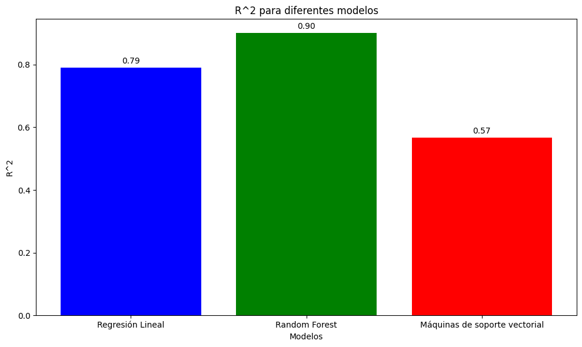

```python
import numpy as np
import matplotlib.pyplot as plt

# Datos para la gráfica del R-squared
models = ['Regresión Lineal', 'Random Forest', 'Máquinas de soporte vectorial']
r2_values = [r2_lr, r2_rf, r2_svm]

# Creación del gráfico de barras para el R-squared
fig, ax = plt.subplots(figsize=(10, 6))

# Barras para cada modelo
rects2 = ax.bar(models, r2_values, color=['blue', 'green', 'red'])

# Añadir etiquetas, título y leyenda
ax.set_xlabel('Modelos')
ax.set_ylabel('R^2')
ax.set_title('R^2 para diferentes modelos')

# Añadir valores en las barras
def add_labels(rects):
    for rect in rects:
        height = rect.get_height()
        ax.annotate(f'{height:.2f}',
                    xy=(rect.get_x() + rect.get_width() / 2, height),
                    xytext=(0, 3),  # 3 puntos de desplazamiento vertical
                    textcoords='offset points',
                    ha='center', va='bottom')

add_labels(rects2)

plt.tight_layout()
plt.show()
```

#### 6.3 Conclusiones

1. Modelo de Regresión Lineal (Pred_LR):
   - Las predicciones están razonablemente cerca de los valores reales, pero hay algunos problemas con valores negativos y una menor desviación estándar que la real.
2. Modelo de Random Forest (Pred_RF):
   - Este modelo proporciona las predicciones más cercanas a los valores reales, capturando mejor la media y la desviación estándar de los datos. Maneja mejor los valores extremos y tiene una mayor precisión general.
3. Modelo de Máquinas de Soporte Vectorial (Pred_SVM):
   - Este modelo subestima sistemáticamente los cargos del seguro y no captura bien la variabilidad de los datos. Tiene una media y una desviación estándar significativamente diferentes de los valores reales, lo que indica un bajo rendimiento en este conjunto de datos.